# Canadian Crude Oil Prices, Net-Zero Scenarios, and Trade Vulnerability to U.S. Policy Risk

Efe Oroh

2025-01-26

# Project Objective

This report produces a series of data visualizations with brief analytical takeaways to examine crude oil price trajectories under energy transition scenarios and Canada's export dependence on the United States. It does this by presenting price projections from the Canada Energy Regulator alongside Canadian crude trade data through targeted visualizations. The objective is to showcase how global decarbonization pathways and concentrated export markets may shape the value and vulnerability of Canadian oil production.

# Deliverable 1 — WCS Price Outlook

Projected Western Canadian Select (WCS) prices rise in the mid-2020s before gradually declining toward 2050 under the Canada Net-Zero scenario, reflecting short-term demand recovery followed by structural demand reductions from the energy transition.

| Western Canadian Select (WCS) prices in the Canada Net-Zero scenario of the Canadian Energy Regulator’s Canada’s Energy Future (2023) report Year | Western Canadian Select (WCS) prices in the Canada Net-Zero scenario of the Canadian Energy Regulator’s Canada’s Energy Future (2023) report Price ($US 2022/bbl) |
| --- | --- |
| 2005 | 54.33 |
| 2010 | 87.08 |
| 2015 | 42.43 |
| 2020 | 29.61 |
| 2025 | 62.33 |
| 2030 | 49.00 |
| 2035 | 48.00 |
| 2040 | 47.00 |
| 2045 | 46.00 |
| 2050 | 45.00 |

# Deliverable 2 — Global Oil Price Comparison

Brent and WTI remain consistently above WCS due to transportation constraints and crude quality differences. The long-term downward trend across benchmarks reflects what would be declining oil demand under net-zero transition scenarios.

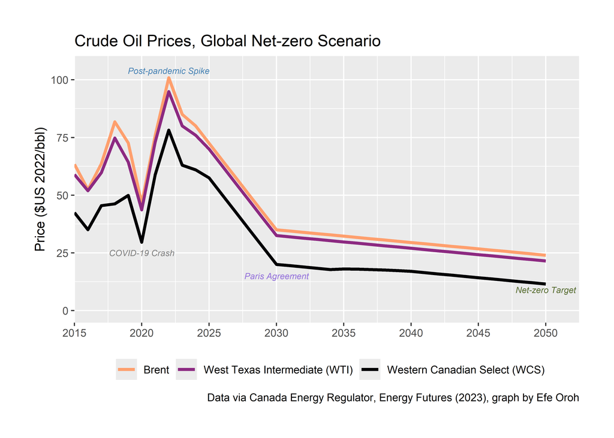

# Deliverable 3 — Net Zero Scenario Comparison (WCS)

Price trajectories vary significantly across scenarios: the Global Net-Zero pathway produces the sharpest decline in WCS prices, while the Current Measures scenario maintains relatively stable prices through mid-century.

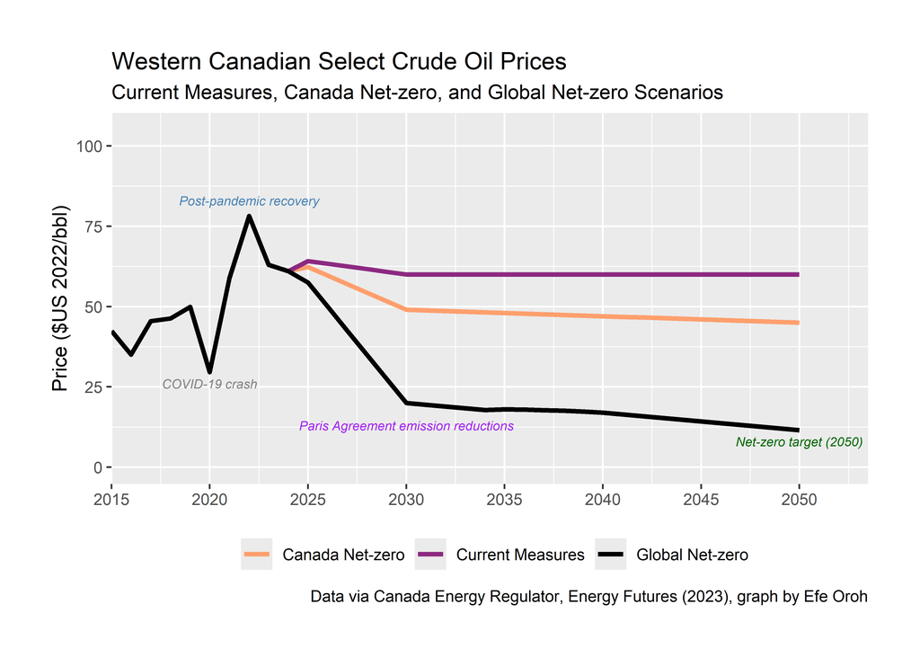

# Deliverable 4 — Canadian Crude Oil Export Value by Trade Route

The graph shows how crucial the United States is to Canadian crude oil exports, with the **"AB to United States"** trade route clearly dominating total export value throughout the period. This reflects how deeply integrated Alberta's oil production is with U.S. refining markets. If tariffs were introduced on Canadian crude, they would raise the effective cost of exporting to the United States, making Canadian oil less competitive compared to domestic or alternative foreign suppliers. In response, U.S. refiners could shift toward cheaper sources, which would likely reduce demand for Canadian crude and lower export revenues for producers.

The chart also shows that exports to **other international markets remain relatively small** compared to flows to the United States. This imbalance highlights Canada's heavy reliance on a single export market and leaves producers exposed to changes in U.S. trade or energy policy.

Overall, the graph underscores Canada's structural dependence on the United States for crude oil exports, particularly for Alberta. Without greater diversification of export routes and markets, Canadian producers remain vulnerable to policy shifts south of the border. Potential tariffs may therefore serve as a reminder of the importance of expanding market access to strengthen the resilience of Canada's oil sector.

[figure not shown]